# NMD Quantiation

Author

Simon Andrews

# Introduction

This is an example of how to take the output of `nmdquant` and look at the nonsense mediated decay activity between two experimental conditions.

The input data here is the output of running:

```
nmdquant.py --outfile nmd_quantiations.txt --nounmeasured Mus_musculus.GRCm39.113.gtf.gz *bam
```

..to quantify the per intron observations of NMD introns in a set of BAM files. In this example the files come from oe of two conditions, a wild type and a knockdown of a gene likely to be involved in RNA processing, and therefore potentially influencing the level of effectiveness of nonsense mediated decay.

# Reading Data

```r
library(tidyverse)
theme_set(theme_bw())
library(ggbeeswarm)
library(rstatix)

read_delim("nmd_quantiations.txt") -> nmd_data

head(nmd_data)
```

| INTRON | DIRECTION | GENE | NMD | Control1_rep1_GRCm39_hisat2.bam | Control1_rep2_GRCm39_hisat2.bam | Control1_rep3_GRCm39_hisat2.bam | Control2_rep1_GRCm39_hisat2.bam | Control2_rep2_GRCm39_hisat2.bam | Control2_rep3_GRCm39_hisat2.bam | KD1_rep1_GRCm39_hisat2.bam | KD1_rep2_GRCm39_hisat2.bam | KD1_rep3_GRCm39_hisat2.bam | KD2_rep1_GRCm39_hisat2.bam | KD2_rep2_GRCm39_hisat2.bam | KD2_rep3_GRCm39_hisat2.bam |
| --- | --- | --- | --- | --- | --- | --- | --- | --- | --- | --- | --- | --- | --- | --- | --- |
| 1:7159441-7190417 | + | Pcmtd1 | FALSE | 135 | 161 | 117 | 154 | 59 | 71 | 99 | 83 | 59 | 69 | 85 | 85 |
| 1:7190840-7217860 | + | Pcmtd1 | FALSE | 48 | 32 | 49 | 43 | 25 | 42 | 24 | 54 | 54 | 27 | 33 | 37 |
| 1:7217964-7231115 | + | Pcmtd1 | FALSE | 99 | 79 | 100 | 96 | 53 | 74 | 62 | 68 | 82 | 75 | 75 | 76 |
| 1:7231288-7233471 | + | Pcmtd1 | FALSE | 77 | 74 | 85 | 68 | 32 | 50 | 42 | 58 | 68 | 60 | 67 | 64 |
| 1:7233596-7239738 | + | Pcmtd1 | FALSE | 51 | 46 | 46 | 59 | 24 | 27 | 29 | 35 | 35 | 50 | 45 | 44 |
| 1:7159441-7217860 | + | Pcmtd1 | FALSE | 52 | 45 | 36 | 29 | 19 | 14 | 47 | 47 | 47 | 49 | 47 | 36 |

## Restructuring

We’ll put this data into tidy format to make some of the normalisation easier. We can also split out the condition and replicate

```r
nmd_data %>%
  pivot_longer(
    cols=Control1_rep1_GRCm39_hisat2.bam:last_col(),
    names_to="filename",
    values_to="count"
  ) %>%
  separate(filename, into=c("condition","replicate"), extra="drop", sep="_", remove = FALSE) -> nmd_long

head(nmd_long)
```

| INTRON | DIRECTION | GENE | NMD | filename | condition | replicate | count |
| --- | --- | --- | --- | --- | --- | --- | --- |
| 1:7159441-7190417 | + | Pcmtd1 | FALSE | Control1_rep1_GRCm39_hisat2.bam | Control1 | rep1 | 135 |
| 1:7159441-7190417 | + | Pcmtd1 | FALSE | Control1_rep2_GRCm39_hisat2.bam | Control1 | rep2 | 161 |
| 1:7159441-7190417 | + | Pcmtd1 | FALSE | Control1_rep3_GRCm39_hisat2.bam | Control1 | rep3 | 117 |
| 1:7159441-7190417 | + | Pcmtd1 | FALSE | Control2_rep1_GRCm39_hisat2.bam | Control2 | rep1 | 154 |
| 1:7159441-7190417 | + | Pcmtd1 | FALSE | Control2_rep2_GRCm39_hisat2.bam | Control2 | rep2 | 59 |
| 1:7159441-7190417 | + | Pcmtd1 | FALSE | Control2_rep3_GRCm39_hisat2.bam | Control2 | rep3 | 71 |

# Normalisation

We want to have globally normalised log transformed values.

```r
nmd_long %>%
  group_by(filename) %>%
  mutate(
    log2RPM = log2(count+1 / (sum(count)/1000000))
  ) %>%
  ungroup() -> nmd_long
```

Let’s compare the distributions we get from this.

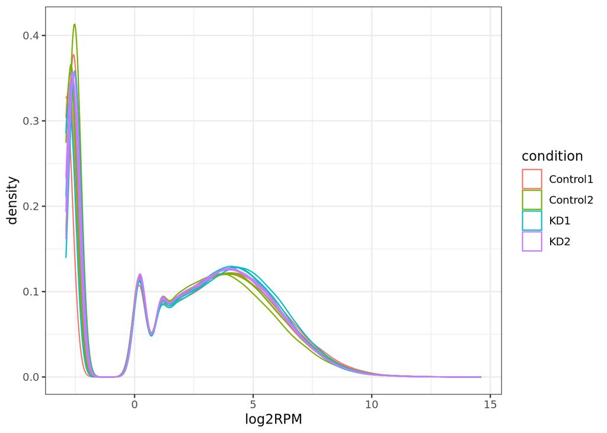

```r
nmd_long %>%
  ggplot(aes(x=log2RPM, group=filename, colour=condition)) +
  geom_density()
```

OK, pretty close.

# Plotting

## NMD proportion

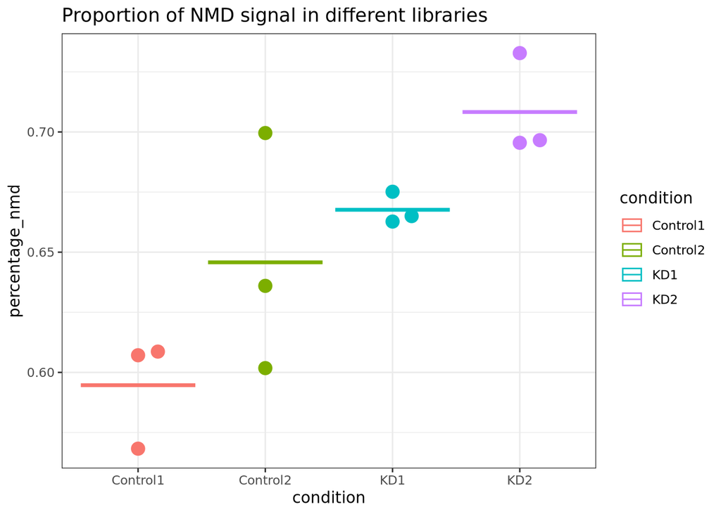

```r
nmd_long %>%
  group_by(filename,condition,NMD) %>%
  summarise(
    count = sum(count)
  ) %>%
  ungroup() %>%
  pivot_wider(
    names_from=NMD,
    values_from=count
  ) %>%
  mutate(
    percentage_nmd = 100*`TRUE`/(`TRUE` + `FALSE`)
  ) %>%
  ggplot(aes(x=condition, y=percentage_nmd, colour=condition)) +
  geom_beeswarm(size=4, cex=4, show.legend = FALSE) +
  stat_summary(geom="crossbar", fun=mean) +
  ggtitle("Proportion of NMD signal in different libraries")
```

## Scatterplot

We can plot a scatterplot of control vs KD and highlight the NMD to see how they change in aggregate.

```r
nmd_long %>%
  group_by(INTRON,NMD,GENE,condition) %>%
  summarise(
    log2RPM = mean(log2RPM)
  ) %>%
  ungroup() %>%
  pivot_wider(
    names_from=condition,
    values_from=log2RPM
  ) -> nmd_summarised_wide
head(nmd_summarised_wide)
```

| INTRON | NMD | GENE | Control1 | Control2 | KD1 | KD2 |
| --- | --- | --- | --- | --- | --- | --- |
| 10:100283606-100284685 | FALSE | Tmtc3 | 4.303550 | 2.999913 | 3.761141 | 3.477024 |
| 10:100284913-100286100 | FALSE | Tmtc3 | 4.147971 | 3.071186 | 3.783542 | 3.595427 |
| 10:100286271-100287243 | FALSE | Tmtc3 | 3.730505 | 2.827577 | 2.940397 | 3.266136 |
| 10:100287348-100292909 | FALSE | Tmtc3 | 5.741854 | 4.265393 | 5.053422 | 4.911093 |
| 10:100293022-100294776 | FALSE | Tmtc3 | 4.708971 | 3.648050 | 3.848231 | 4.393874 |
| 10:100294898-100296821 | FALSE | Tmtc3 | 5.634525 | 4.951905 | 5.567015 | 5.381742 |

### Control1 vs KD1

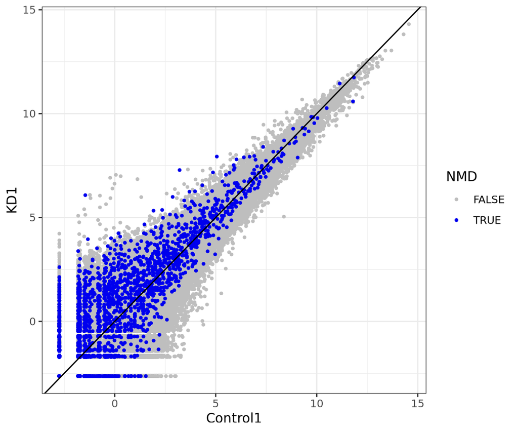

```r
nmd_summarised_wide %>%
  arrange(NMD) %>%
  ggplot(aes(x=Control1, y=KD1, colour=NMD)) +
  geom_point(size=0.8) +
  scale_colour_manual(values=c("grey","blue2")) +
  geom_abline(slope=1, intercept=0)
```

### Control2 vs KD2

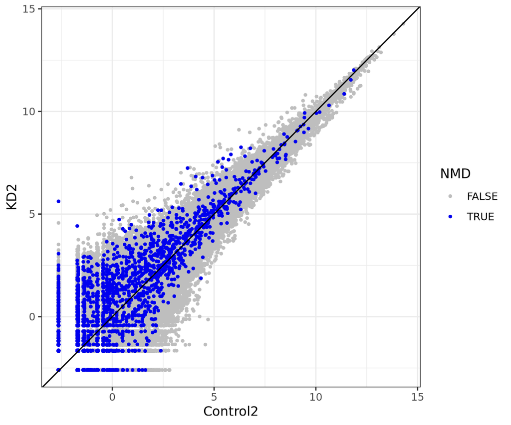

```r
nmd_summarised_wide %>%
  arrange(NMD) %>%
  ggplot(aes(x=Control2, y=KD2, colour=NMD)) +
  geom_point(size=0.8) +
  scale_colour_manual(values=c("grey","blue2")) +
  geom_abline(slope=1, intercept=0)
```

## MA Plot

We can plot a MA of control vs KD and highlight the NMD to see how they change in aggregate.

### Control1 vs KD1

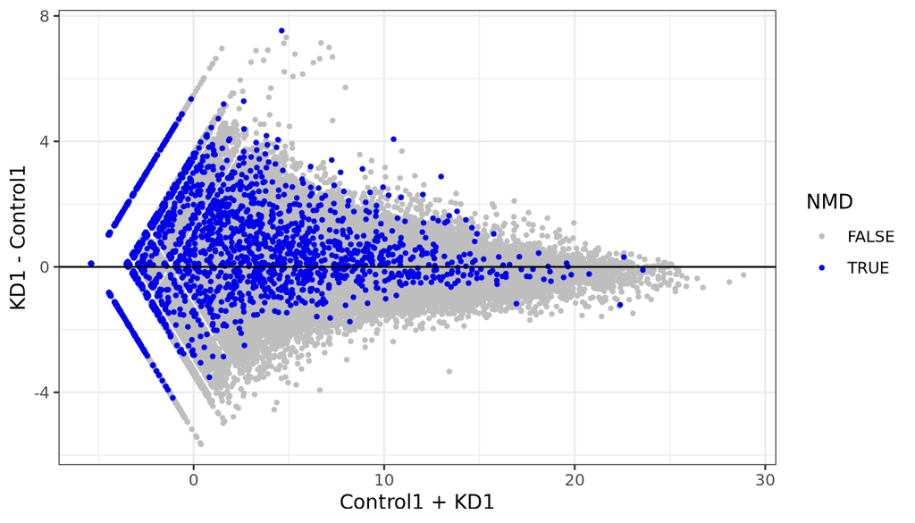

```r
nmd_summarised_wide %>%
  arrange(NMD) %>%
  ggplot(aes(x=Control1+KD1, y=KD1-Control1, colour=NMD)) +
  geom_point(size=0.8) +
  scale_colour_manual(values=c("grey","blue2")) +
  geom_hline(yintercept = 0)
```

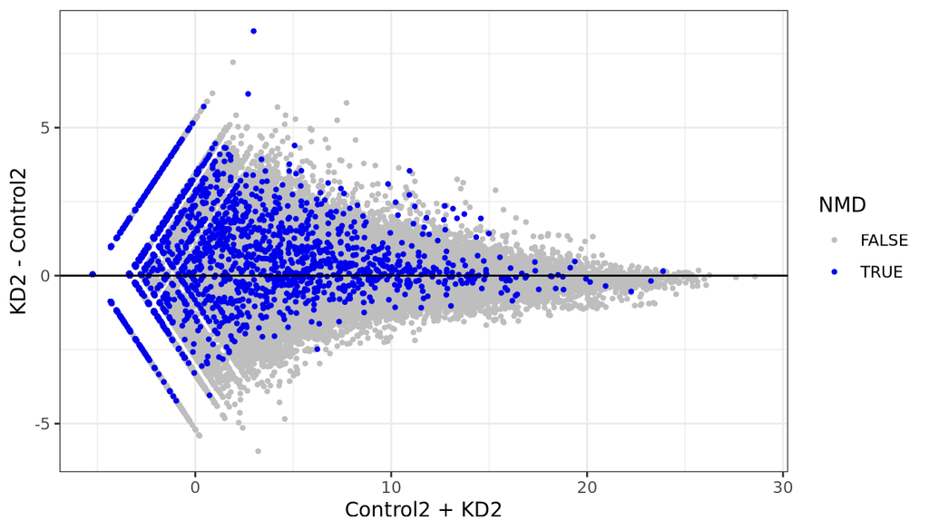

```r
nmd_summarised_wide %>%
  arrange(NMD) %>%
  ggplot(aes(x=Control2+KD2, y=KD2-Control2, colour=NMD)) +
  geom_point(size=0.8) +
  scale_colour_manual(values=c("grey","blue2")) +
  geom_hline(yintercept = 0)
```

## Control1 vs KD1

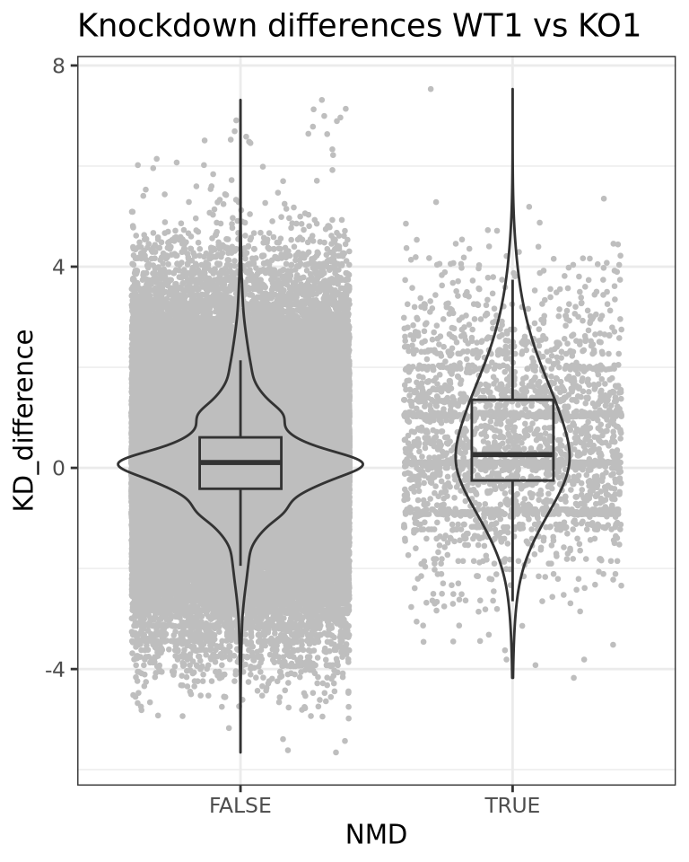

```r
nmd_summarised_wide %>%
  mutate(KD_difference = KD1 - Control1) %>%
  ggplot(aes(x=NMD, y=KD_difference)) +
  geom_jitter(colour="grey", size=0.5) +
  geom_violin(alpha=0, adjust=3) +
  geom_boxplot(alpha=0, width=0.3) +
  ggtitle("Knockdown differences WT1 vs KO1")
```

## Control2 vs KD2

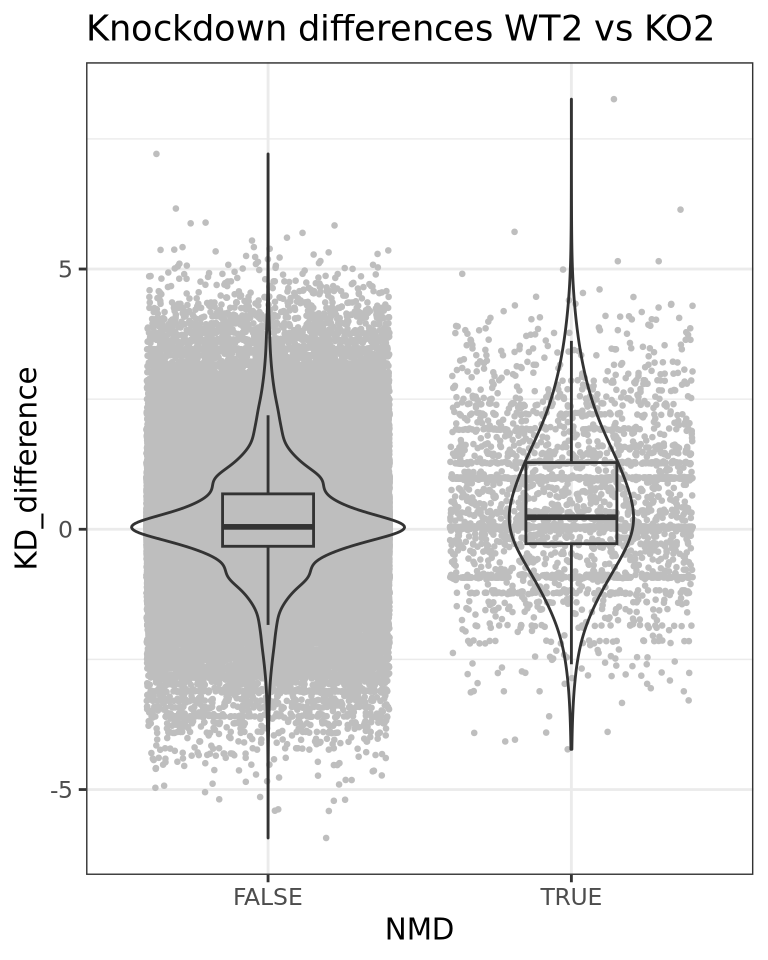

```r
nmd_summarised_wide %>%
  mutate(KD_difference = KD2 - Control2) %>%
  ggplot(aes(x=NMD, y=KD_difference)) +
  geom_jitter(colour="grey", size=0.5) +
  geom_violin(alpha=0, adjust=3) +
  geom_boxplot(alpha=0, width=0.3) +
  ggtitle("Knockdown differences WT2 vs KO2")
```

# Statistics

There are several ways to look at the statistics for this.

## Overall library percentages

```r
nmd_long %>%
  group_by(filename,condition,NMD) %>%
  summarise(
    count = sum(count)
  ) %>%
  ungroup() %>%
  pivot_wider(
    names_from=NMD,
    values_from=count
  ) %>%
  mutate(
    percentage_nmd = 100*`TRUE`/(`TRUE` + `FALSE`)
  ) %>%
  t_test(percentage_nmd~condition) %>%
  filter((group1=="Control1" & group2=="KD1")|(group1=="Control2" & group2=="KD2")) %>%
  select(group1,group2,p)
```

| group1 | group2 | p |
| --- | --- | --- |
| Control1 | KD1 | 0.024 |
| Control2 | KD2 | 0.148 |

## Distribution of differences

## Control1 vs KD1

```r
nmd_summarised_wide %>%
  mutate(KD_difference = KD1 - Control1) %>%
  wilcox_test(KD_difference ~ NMD)
```

|  | .y. | group1 | group2 | n1 | n2 | statistic | p |
| --- | --- | --- | --- | --- | --- | --- | --- |
| 1 | KD_difference | FALSE | TRUE | 163257 | 2941 | 193535956 | 8.29e-73 |

## Control2 vs KD2

```r
nmd_summarised_wide %>%
  mutate(KD_difference = KD2 - Control2) %>%
  wilcox_test(KD_difference ~ NMD)
```

|  | .y. | group1 | group2 | n1 | n2 | statistic | p |
| --- | --- | --- | --- | --- | --- | --- | --- |
| 1 | KD_difference | FALSE | TRUE | 163257 | 2941 | 205322336 | 2.16e-41 |

Both of these are highly significant, but we may be over-powered.